# The Otto Group Classification

First, let’s load the packages and the dataset.

```r
require(rpart)
require(randomForest)
require(gbm)
```

Load data

```r
train <- read.csv("train.csv")
test <- read.csv("test.csv")
samplesub <- read.csv("sampleSubmission.csv")
```

Let’s explore the dataset.

```r
summary(train)
```

```
##        id            feat_1            feat_2            feat_3
##  Min.   :    1   Min.   : 0.0000   Min.   : 0.0000   Min.   : 0.0000
##  1st Qu.:15470   1st Qu.: 0.0000   1st Qu.: 0.0000   1st Qu.: 0.0000
##  Median :30940   Median : 0.0000   Median : 0.0000   Median : 0.0000
##  Mean   :30940   Mean   : 0.3867   Mean   : 0.2631   Mean   : 0.9015
##  3rd Qu.:46409   3rd Qu.: 0.0000   3rd Qu.: 0.0000   3rd Qu.: 0.0000
##  Max.   :61878   Max.   :61.0000   Max.   :51.0000   Max.   :64.0000
##
##      feat_4            feat_5             feat_6            feat_7
##  Min.   : 0.0000   Min.   : 0.00000   Min.   : 0.0000   Min.   : 0.0000
##  1st Qu.: 0.0000   1st Qu.: 0.00000   1st Qu.: 0.0000   1st Qu.: 0.0000
##  Median : 0.0000   Median : 0.00000   Median : 0.0000   Median : 0.0000
##  Mean   : 0.7791   Mean   : 0.07104   Mean   : 0.0257   Mean   : 0.1937
##  3rd Qu.: 0.0000   3rd Qu.: 0.00000   3rd Qu.: 0.0000   3rd Qu.: 0.0000
##  Max.   :70.0000   Max.   :19.00000   Max.   :10.0000   Max.   :38.0000
##
##      feat_8            feat_9          feat_10           feat_11
##  Min.   : 0.0000   Min.   : 0.000   Min.   : 0.0000   Min.   : 0.000
##  1st Qu.: 0.0000   1st Qu.: 0.000   1st Qu.: 0.0000   1st Qu.: 0.000
##  Median : 0.0000   Median : 0.000   Median : 0.0000   Median : 0.000
##  Mean   : 0.6624   Mean   : 1.011   Mean   : 0.2639   Mean   : 1.253
##  3rd Qu.: 1.0000   3rd Qu.: 0.000   3rd Qu.: 0.0000   3rd Qu.: 1.000
##  Max.   :76.0000   Max.   :43.000   Max.   :30.0000   Max.   :38.000
##
##     feat_12           feat_13          feat_14          feat_15
##  Min.   : 0.0000   Min.   : 0.000   Min.   : 0.000   Min.   : 0.000
##  1st Qu.: 0.0000   1st Qu.: 0.000   1st Qu.: 0.000   1st Qu.: 0.000
##  Median : 0.0000   Median : 0.000   Median : 0.000   Median : 0.000
##  Mean   : 0.1409   Mean   : 0.481   Mean   : 1.697   Mean   : 1.284
##  3rd Qu.: 0.0000   3rd Qu.: 0.000   3rd Qu.: 2.000   3rd Qu.: 1.000
##  Max.   :30.0000   Max.   :72.000   Max.   :33.000   Max.   :46.000
##
##     feat_16          feat_17           feat_18           feat_19
##  Min.   : 0.000   Min.   : 0.0000   Min.   : 0.0000   Min.   :  0.0000
##  1st Qu.: 0.000   1st Qu.: 0.0000   1st Qu.: 0.0000   1st Qu.:  0.0000
##  Median : 0.000   Median : 0.0000   Median : 0.0000   Median :  0.0000
##  Mean   : 1.413   Mean   : 0.3661   Mean   : 0.5754   Mean   :  0.5517
##  3rd Qu.: 2.000   3rd Qu.: 0.0000   3rd Qu.: 1.0000   3rd Qu.:  0.0000
##  Max.   :37.000   Max.   :43.0000   Max.   :32.0000   Max.   :121.0000
##
```

[output cut: 137 more lines]

```
##  Min.   : 0.0000   Min.   : 0.0000   Min.   :  0.0000   Min.   : 0.0000
##  1st Qu.: 0.0000   1st Qu.: 0.0000   1st Qu.:  0.0000   1st Qu.: 0.0000
##  Median : 0.0000   Median : 0.0000   Median :  0.0000   Median : 0.0000
##  Mean   : 0.8749   Mean   : 0.4578   Mean   :  0.8124   Mean   : 0.2649
##  3rd Qu.: 1.0000   3rd Qu.: 0.0000   3rd Qu.:  0.0000   3rd Qu.: 0.0000
##  Max.   :30.0000   Max.   :61.0000   Max.   :130.0000   Max.   :52.0000
##
##     feat_92           feat_93            target
##  Min.   : 0.0000   Min.   : 0.0000   Class_2:16122
##  1st Qu.: 0.0000   1st Qu.: 0.0000   Class_6:14135
##  Median : 0.0000   Median : 0.0000   Class_8: 8464
##  Mean   : 0.3801   Mean   : 0.1261   Class_3: 8004
##  3rd Qu.: 0.0000   3rd Qu.: 0.0000   Class_9: 4955
##  Max.   :19.0000   Max.   :87.0000   Class_7: 2839
##                                      (Other): 7359
```

```r
summary(test)
```

```
##        id             feat_1            feat_2            feat_3
##  Min.   :     1   Min.   : 0.0000   Min.   : 0.0000   Min.   : 0.0000
##  1st Qu.: 36093   1st Qu.: 0.0000   1st Qu.: 0.0000   1st Qu.: 0.0000
##  Median : 72185   Median : 0.0000   Median : 0.0000   Median : 0.0000
##  Mean   : 72185   Mean   : 0.3862   Mean   : 0.2636   Mean   : 0.8998
##  3rd Qu.:108276   3rd Qu.: 0.0000   3rd Qu.: 0.0000   3rd Qu.: 0.0000
##  Max.   :144368   Max.   :64.0000   Max.   :45.0000   Max.   :84.0000
##      feat_4            feat_5            feat_6             feat_7
##  Min.   : 0.0000   Min.   : 0.0000   Min.   : 0.00000   Min.   : 0.0000
##  1st Qu.: 0.0000   1st Qu.: 0.0000   1st Qu.: 0.00000   1st Qu.: 0.0000
##  Median : 0.0000   Median : 0.0000   Median : 0.00000   Median : 0.0000
##  Mean   : 0.7807   Mean   : 0.0715   Mean   : 0.02644   Mean   : 0.2002
##  3rd Qu.: 0.0000   3rd Qu.: 0.0000   3rd Qu.: 0.00000   3rd Qu.: 0.0000
##  Max.   :82.0000   Max.   :14.0000   Max.   :11.00000   Max.   :44.0000
##      feat_8             feat_9          feat_10           feat_11
##  Min.   :  0.0000   Min.   : 0.000   Min.   : 0.0000   Min.   : 0.000
##  1st Qu.:  0.0000   1st Qu.: 0.000   1st Qu.: 0.0000   1st Qu.: 0.000
##  Median :  0.0000   Median : 0.000   Median : 0.0000   Median : 0.000
##  Mean   :  0.6674   Mean   : 1.035   Mean   : 0.2688   Mean   : 1.254
##  3rd Qu.:  1.0000   3rd Qu.: 0.000   3rd Qu.: 0.0000   3rd Qu.: 1.000
##  Max.   :100.0000   Max.   :47.000   Max.   :59.0000   Max.   :37.000
##     feat_12           feat_13           feat_14        feat_15
##  Min.   : 0.0000   Min.   : 0.0000   Min.   : 0.0   Min.   : 0.00
##  1st Qu.: 0.0000   1st Qu.: 0.0000   1st Qu.: 0.0   1st Qu.: 0.00
##  Median : 0.0000   Median : 0.0000   Median : 0.0   Median : 0.00
##  Mean   : 0.1437   Mean   : 0.4864   Mean   : 1.7   Mean   : 1.29
##  3rd Qu.: 0.0000   3rd Qu.: 0.0000   3rd Qu.: 2.0   3rd Qu.: 1.00
##  Max.   :30.0000   Max.   :75.0000   Max.   :34.0   Max.   :39.00
##     feat_16          feat_17           feat_18           feat_19
##  Min.   : 0.000   Min.   : 0.0000   Min.   : 0.0000   Min.   :  0.0000
##  1st Qu.: 0.000   1st Qu.: 0.0000   1st Qu.: 0.0000   1st Qu.:  0.0000
##  Median : 0.000   Median : 0.0000   Median : 0.0000   Median :  0.0000
##  Mean   : 1.428   Mean   : 0.3662   Mean   : 0.5824   Mean   :  0.5607
##  3rd Qu.: 2.000   3rd Qu.: 0.0000   3rd Qu.: 1.0000   3rd Qu.:  0.0000
##  Max.   :46.000   Max.   :49.0000   Max.   :30.0000   Max.   :128.0000
##     feat_20           feat_21           feat_22           feat_23
##  Min.   : 0.0000   Min.   : 0.0000   Min.   : 0.0000   Min.   : 0.0000
##  1st Qu.: 0.0000   1st Qu.: 0.0000   1st Qu.: 0.0000   1st Qu.: 0.0000
##  Median : 0.0000   Median : 0.0000   Median : 0.0000   Median : 0.0000
##  Mean   : 0.4843   Mean   : 0.2026   Mean   : 0.7386   Mean   : 0.1407
```

[output cut: 113 more lines]

```
##  Max.   :132.00000   Max.   :56.0000   Max.   :73.000   Max.   :54.0000
##     feat_88           feat_89           feat_90           feat_91
##  Min.   : 0.0000   Min.   : 0.0000   Min.   :  0.000   Min.   : 0.0000
##  1st Qu.: 0.0000   1st Qu.: 0.0000   1st Qu.:  0.000   1st Qu.: 0.0000
##  Median : 0.0000   Median : 0.0000   Median :  0.000   Median : 0.0000
##  Mean   : 0.8755   Mean   : 0.4733   Mean   :  0.814   Mean   : 0.2712
##  3rd Qu.: 1.0000   3rd Qu.: 0.0000   3rd Qu.:  0.000   3rd Qu.: 0.0000
##  Max.   :37.0000   Max.   :62.0000   Max.   :119.000   Max.   :74.0000
##     feat_92           feat_93
##  Min.   : 0.0000   Min.   : 0.0000
##  1st Qu.: 0.0000   1st Qu.: 0.0000
##  Median : 0.0000   Median : 0.0000
##  Mean   : 0.3883   Mean   : 0.1327
##  3rd Qu.: 0.0000   3rd Qu.: 0.0000
##  Max.   :22.0000   Max.   :91.0000
```

Each column represents a feature measured by an integer. Each row is an Otto product.

Obviously the first column (ID) doesn’t contain any useful information.

To let the algorithm focus on real stuff, we will delete it.

```r
train <- train[,-1]
```

Create sample train and test datasets for prototyping new models from the train dataset

```r
strain <- train[sample(nrow(train), 10000, replace=FALSE),]
stest <- train[sample(nrow(train), 5000, replace=FALSE),]
```

Create a decision tree model using the target field as the response and all 93 features

```r
#Set a unique seed number so you get the same results everytime you run the below model,
# the number does not matter
set.seed(13)
fit1 <- rpart(as.factor(target) ~ ., data=train, method="class")
# Plot the decision tree
```

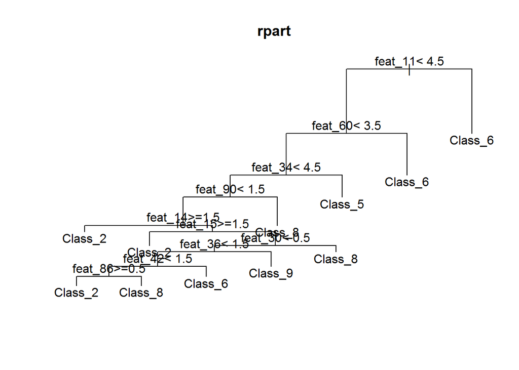

```r
par(xpd=TRUE)
plot(fit1, compress=TRUE)
title(main="rpart")
text(fit1)
```

```r
fit1.pred <- predict(fit1, stest, type="class")
```

Create a confusion matrix of predictions vs actuals

```r
table(fit1.pred,stest$target)
```

```
##
## fit1.pred Class_1 Class_2 Class_3 Class_4 Class_5 Class_6 Class_7 Class_8
##   Class_1       0       0       0       0       0       0       0       0
##   Class_2      32    1205     544     181       5      45     129      68
##   Class_3       0       0       0       0       0       0       0       0
##   Class_4       0       0       0       0       0       0       0       0
##   Class_5       0      12      16       5     195       3       5       4
##   Class_6      14       4       1      11       0    1004      19      46
##   Class_7       0       0       0       0       0       0       0       0
##   Class_8      69      79      50      12      15      98      77     540
##   Class_9      33       8       6       2       0      24       6      27
##
## fit1.pred Class_9
##   Class_1       0
##   Class_2     120
##   Class_3       0
##   Class_4       0
##   Class_5       2
##   Class_6      25
##   Class_7       0
##   Class_8     106
##   Class_9     153
```

Determine the error rate for the model

```r
fit1$error <- 1-(sum(fit1.pred==stest$target)/length(stest$target))
fit1$error
```

```
## [1] 0.3806
```

Create a random forest model

```r
set.seed(16)
fit2 <- randomForest(as.factor(target) ~ ., data=strain, importance=TRUE, ntree=50, mtry=2)
```

Create a dotchart of variable/feature importance as measured by a Random Forest

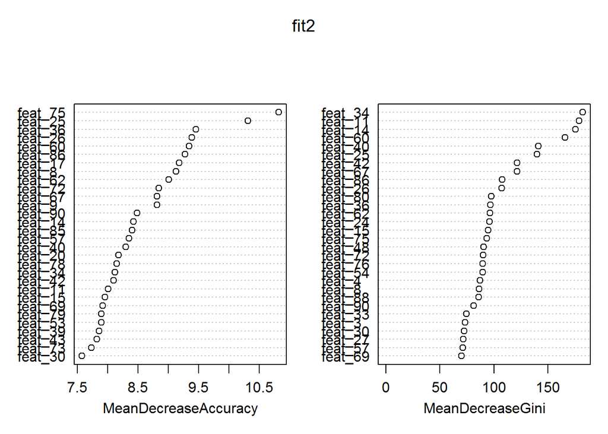

```r
varImpPlot(fit2)
```

Test the randomForest model on the holdout test dataset

```r
fit2.pred <- predict(fit2, stest, type="response")
```

Create a confusion matrix of predictions vs actuals

```r
table(fit2.pred,stest$target)
```

```
##
## fit2.pred Class_1 Class_2 Class_3 Class_4 Class_5 Class_6 Class_7 Class_8
##   Class_1      25       0       0       0       0       0       0       1
##   Class_2      21    1265     457     161      15      26      72      16
##   Class_3       1      27     145      12       0       4      10       1
##   Class_4       0       1       0      25       0       0       1       0
##   Class_5       5       2       0       2     195       2       3       1
##   Class_6      28       9       8       9       5    1106      35      46
##   Class_7       1       2       2       0       0       4      80       0
##   Class_8      38       2       5       0       0      24      34     615
##   Class_9      29       0       0       2       0       8       1       5
##
## fit2.pred Class_9
##   Class_1       1
##   Class_2      34
##   Class_3       0
##   Class_4       0
##   Class_5       1
##   Class_6      18
##   Class_7       0
##   Class_8      22
##   Class_9     330
```

Determine the error rate for the model

```r
fit2$error <- 1-(sum(fit2.pred==stest$target)/length(stest$target))
fit2$error
```

```
## [1] 0.2428
```

Create gradient boosting model

```r
set.seed(17)
fit3 <- gbm(target ~ ., data=strain, distribution="multinomial", n.trees=1000,
            shrinkage=0.05, interaction.depth=12)
```

Test the boosting model on the holdout test dataset

```r
trees <- gbm.perf(fit3)
```

```
## Using OOB method...
```

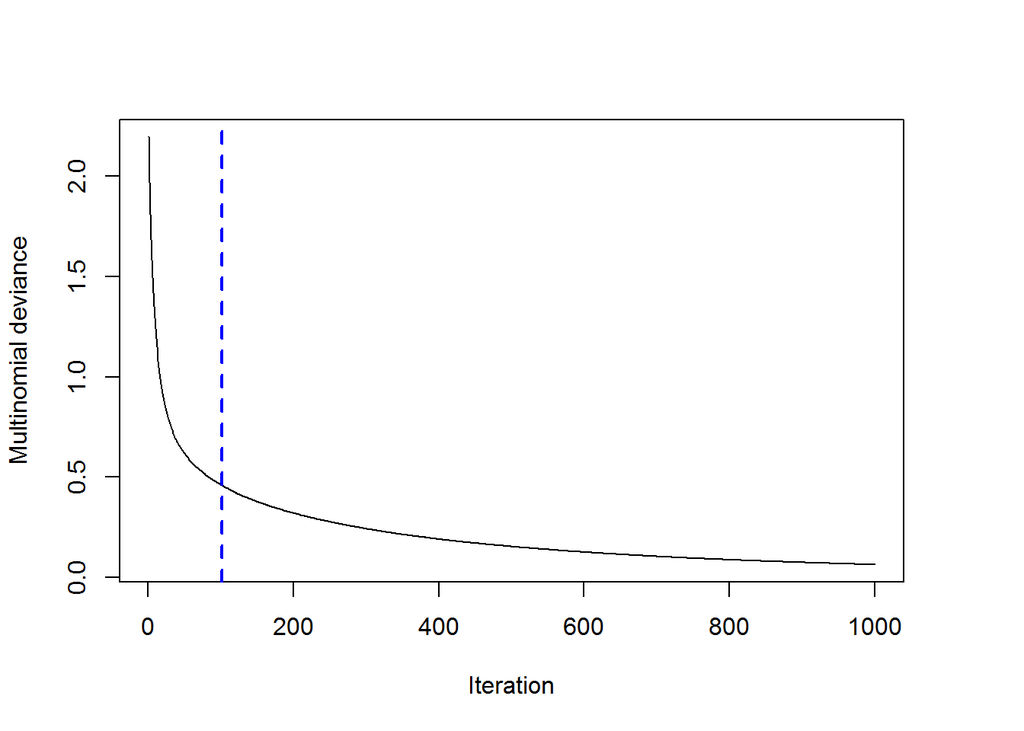

```r
fit3.stest <- predict(fit3, stest, n.trees=trees, type="response")
fit3.stest <- as.data.frame(fit3.stest)
names(fit3.stest) <- c("Class_1","Class_2","Class_3","Class_4","Class_5","Class_6","Class_7","Class_8","Class_9")
fit3.stest.pred <- rep(NA,2000)
for (i in 1:nrow(stest)) {
  fit3.stest.pred[i] <- colnames(fit3.stest)[(which.max(fit3.stest[i,]))]}
fit3.pred <- as.factor(fit3.stest.pred)
```

Create a confusion matrix of predictions vs actuals

```r
table(fit3.pred,stest$target)
```

```
##
## fit3.pred Class_1 Class_2 Class_3 Class_4 Class_5 Class_6 Class_7 Class_8
##   Class_1      57       1       0       0       0       3       4      10
##   Class_2      19    1148     305      95       9      21      39      14
##   Class_3       2     132     283      31       1       2      16       4
##   Class_4       0      12      14      71       0       2       1       0
##   Class_5       0       2       0       2     203       0       1       3
##   Class_6      13       1       2       9       1    1092      21      11
##   Class_7       1       9       8       3       0       7     135       1
##   Class_8      31       2       5       0       1      35      19     638
##   Class_9      25       1       0       0       0      12       0       4
##
## fit3.pred Class_9
##   Class_1       5
##   Class_2      18
##   Class_3       2
##   Class_4       0
##   Class_5       1
##   Class_6      13
##   Class_7       1
##   Class_8      23
##   Class_9     343
```

Determine the error rate for the model

```r
fit3$error <- 1-(sum(fit3.pred==stest$target)/length(stest$target))
fit3$error
```

```
## [1] 0.206
```